Introduction: Theoretical Argument, Hypotheses and Data

When a state forms a foreign alliance with another state, it likely does not only consider that state in itself, but also the network it is embedded in. Rather than solely dyadic-based considerations, states’ position in the network, and their geostrategic and economic embeddedness therefore matter for alliance formation.

Asking the question of what could explain the alliance network structure in the year 2012, I want to first examine explanations related to homophily, before looking at partial conditional dependencies.

More specifically, the dyadic effects I focus on are homophily in terms of a shared subcontinent, similar human development, and level of democratic freedom. I then also hypothesize that there is a clustering around repeated alliance choice.

In order to examine these hypotheses, I merge a dyadic, directed network [dataset](https://correlatesofwar.org/data-sets/formal-alliances) from the Correlates of War Project with [data on political rights](https://freedomhouse.org/reports/publication-archives) from Freedom House (ordinal values from 1 to 7), and with the UN’s [human development index](http://hdr.undp.org/en/data).

Prettier Overview of Hypotheses:

```r
a<-"Dyad independence"
b1<-"Countries are more likely to form alliances if they have a) matching regions"
b2<- "... b) matching levels of political rights"
b3<- "... c) matching levels of human development"
c<- "Partial conditional dependency"
d<-"Alliances cluster around repeated alliance choice"

a1<-cbind(a,b1)
a2<-cbind(a,b2)
a3<-cbind(a,b3)
b<-cbind(c,d)

Hypotheses<-rbind(a1,a2,a3,b)
colnames(Hypotheses)<-c("Level of Dependence", "Hypothesis")
rownames(Hypotheses)<-c("H1a", "H1b", "H1c", "H2")

##View(Hypotheses) to see table
```

Building the Dataset

```r
#Downloading COW Foreign Alliances Dataset
library(haven)
library(foreign)
library(igraph)
data<-read_dta("/Users/leaschaad/Desktop/This/alliance_v4.1_by_directed_yearly.dta")
##filter by year 2012
library(dplyr)
library(ggplot2)
data<-subset(data, year == 2012)
## Restricting to dyads
data<-select(data, state_name1, state_name2)

#Downloading Freedom House Region and Democracy Attributes Dataset
library(readxl)
fh<-read_xls("/Users/leaschaad/Desktop/This/All_data_FIW_2013-2021.xls")
##restricting to year 2013
fh<-subset(fh, Edition == "2013") ###didn't have 2012, but 2013 is very similar
##restricting fh to Country, Region, Status, political rights score, and civil liberties score
##and matching names to COW dataset for merging
fh<-select(fh, "Country/Territory", Region, "PR rating")
fh<-rename(fh, "PR" = "PR rating")
fh$PR<-as.numeric(fh$PR)

fh$"Country/Territory"[fh$"Country/Territory" == "United States"]<-"United States of America"
fh$"Country/Territory"[fh$"Country/Territory" == "Antigua and Barbuda"]<-"Antigua & Barbuda"
fh$"Country/Territory"[fh$"Country/Territory" == "The Gambia"]<-"Gambia"
fh$"Country/Territory"[fh$"Country/Territory" == "Cabo Verde"]<-"Cape Verde"
fh$"Country/Territory"[fh$"Country/Territory" == "Cote d'Ivoire"]<-"Ivory Coast"
fh$"Country/Territory"[fh$"Country/Territory" == "Congo (Brazzaville)"]<-"Democratic Republic of the Congo"
fh$"Country/Territory"[fh$"Country/Territory" == "Congo (Kinshasa)"]<-"Congo"

#Downloading HDI dataset:

library(readxl)
hdi<-read_xls("/Users/leaschaad/Desktop/This/HumanDevelopmentIndex.xls")
```

```
## * `` -> ...4
## * `` -> ...6
## * `` -> ...8
## * `` -> ...10
## * `` -> ...12
## * ...
```

```r
hdi<-select(hdi, Country, "2012")
hdi<-rename(hdi, "hdi" = "2012")
hdi$hdi<-as.numeric(hdi$hdi)
```

```r
##matching names to COW dataset for merging
hdi$Country[hdi$Country == "Bolivia (Plurinational State of)"]<-"Bolivia"
hdi$Country[hdi$Country == "United States"]<-"United States of America"
hdi$Country[hdi$Country == "Venezuela (Bolivarian Republic of)"]<-"Venezuela"
hdi$Country[hdi$Country == "Syrian Arab Republic"]<-"Syria"
hdi$Country[hdi$Country == "Saint Lucia"]<-"St. Lucia"
hdi$Country[hdi$Country == "Saint Kitts and Nevis"]<-"St. Kitts and Nevis"
hdi$Country[hdi$Country == "Saint Vincent and the Grenadines"]<-"St. Vincent and the Grenadines"
hdi$Country[hdi$Country == "Antigua and Barbuda"]<-"Antigua & Barbuda"
hdi$Country[hdi$Country == "Czechia"]<-"Czech Republic"
hdi$Country[hdi$Country == "Korea (Republic of)"]<-"South Korea"
hdi$Country[hdi$Country == "Russian Federation"]<-"Russia"
hdi$Country[hdi$Country == "Moldova (Republic of)"]<-"Moldova"
hdi$Country[hdi$Country == "Eswatini (Kingdom of)"]<-"Swaziland"
data$state_name1[data$state_name1 == "German Federal Republic"]<-"Germany"
data$state_name2[data$state_name2 == "German Federal Republic"]<-"Germany"

#Merging Datasets to one
library(igraph)
library(migraph)
library(dplyr)

merged<-left_join(data, fh, by = c("state_name1" = "Country/Territory"))
merged<-left_join(merged, hdi, by = c("state_name1" = "Country"))

#Factorizing PR and hdi

library(ggplot2)
merged$hdi<-cut_number(merged$hdi, n = 3, labels = c("low", "medium", "high"))
merged$PR<-cut_number(merged$PR, n = 3, labels = c("low", "medium", "high"))

table(merged$hdi)
```

```
##
##    low medium   high
##   1022    991    996
```

```r
table(merged$PR)
```

```
##
##    low medium   high
##   1419    839    853
```

```r
#Dealing with NAs - they have to go because ergm can't deal with them
merged$hdi<-as.character(merged$hdi)
merged$PR<-as.character(merged$PR)
merged[is.na(merged)] = "Recode" ##Recoding all NAs to "Recode", because R didn't seem to recognize NAs otherwise - must be character variables for this to work

merged$hdi[merged$hdi == "Recode"]<-"medium"
merged$PR[merged$PR == "Recode"]<-"medium"
merged$Region[merged$Region == "Recode"]<-"Other"

#turning into graph object that takes first two as edge list and other columns as attributes
library(igraph)
alliance<-graph_from_data_frame(merged[, 1:2], directed = TRUE, vertices = merged[!duplicated(merged[,1]), c(1, 3:5)])
summary(alliance)
```

```
## IGRAPH eeb09a1 DN-- 141 3114 --
## + attr: name (v/c), Region (v/c), PR (v/c), hdi (v/c)
```

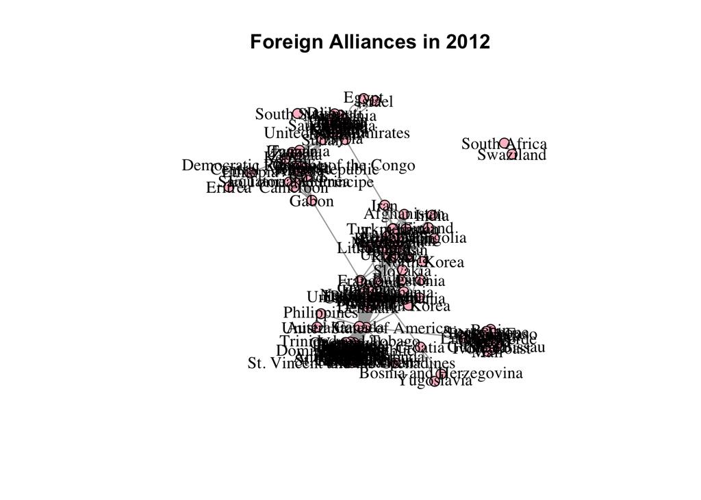

```r
V(alliance)$color<-"pink"
plot(alliance, vertex.size = 7, label.size = .1, vertex.label.color = "black", edge.arrow.size = 0.1 , edge.arrow.width = 0.5)
title(main = "Foreign Alliances in 2012") ##taking a first look at the network - enlarge to read names. If you want to be able to read the names, save this as a pdf while enlarging x10. Otherwise, view it without vertex labels with the code below:
```

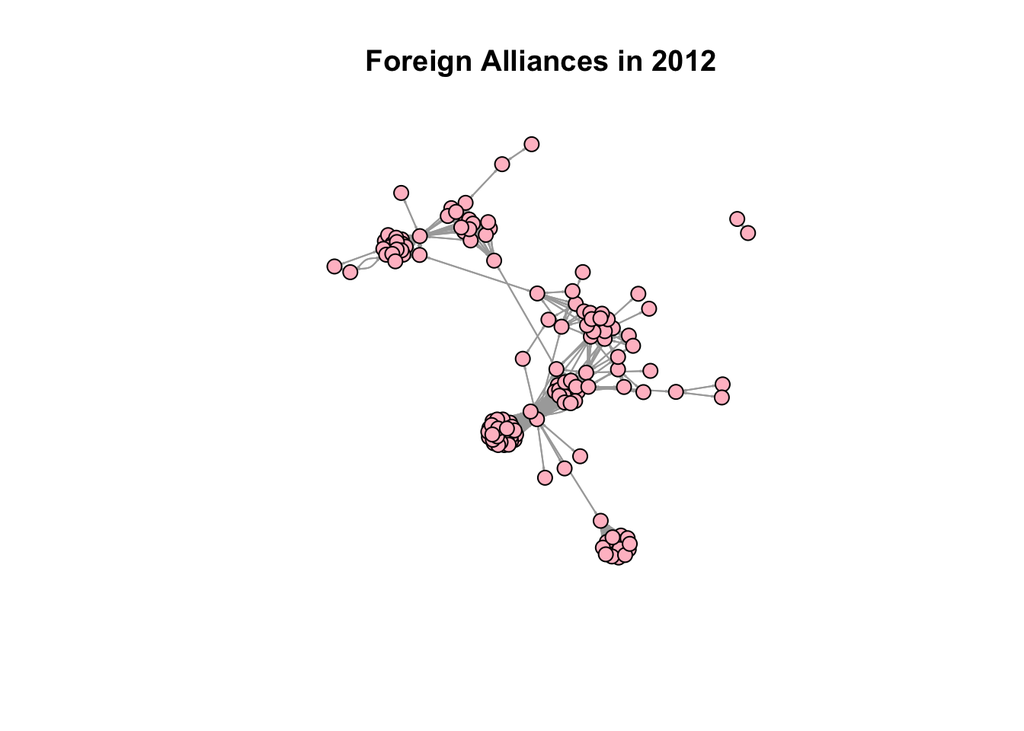

```r
plot(alliance, vertex.size = 7, vertex.label = NA, edge.arrow.size = 0.1 , edge.arrow.width = 0.5)
title(main = "Foreign Alliances in 2012")
```

```r
#Turning into network object
library(ergm)
```

```r
library(intergraph)
alliance2<-alliance
alliance2 <- intergraph::asNetwork(alliance)
##So now I have a graph object (alliance) and a network object (alliance2)
```

Looking at Data - Basic measures

```r
library(migraph)
library(igraph)
##Density e.g. the proportion of ties in a network
edge_density(alliance) #0.1577508
```

```
## [1] 0.1577508
```

```r
##Transitivity
transitivity(alliance) #0.9065951
```

```
## [1] 0.9065951
```

```r
reciprocity(alliance) #1 --> Every tie is reciprocated
```

```
## [1] 1
```

Now that we have built the dataset, let’s look at some basic measures. We can see that the network is not very dense, is fully reciprocal, and has many three-cycles. But can the network be explained by randomness, or is there at least some level of dependence going on?

Network Visualization

```r
#Comparing Network to Random Network
model1 <- ergm(alliance2 ~ edges)
```

```
## Starting maximum pseudolikelihood estimation (MPLE):
```

```
## Evaluating the predictor and response matrix.
```

```
## Maximizing the pseudolikelihood.
```

```
## Finished MPLE.
```

```
## Stopping at the initial estimate.
```

```
## Evaluating log-likelihood at the estimate.
```

```r
summary(model1)
```

```
## Call:
## ergm(formula = alliance2 ~ edges)
##
## Maximum Likelihood Results:
##
##       Estimate Std. Error MCMC % z value Pr(>|z|)
## edges -1.93186    0.02141      0  -90.24   <1e-04 ***
## ---
## Signif. codes:  0 '***' 0.001 '**' 0.01 '*' 0.05 '.' 0.1 ' ' 1
##
##      Null Deviance: 27365  on 19740  degrees of freedom
##  Residual Deviance: 14993  on 19739  degrees of freedom
##
## AIC: 14995  BIC: 15003  (Smaller is better. MC Std. Err. = 0)
```

```r
(sim <- simulate(model1))
```

```
##  Network attributes:
##   vertices = 141
##   directed = TRUE
##   hyper = FALSE
##   loops = FALSE
##   multiple = TRUE
##   bipartite = FALSE
##   total edges= 2467
##     missing edges= 0
##     non-missing edges= 2467
##
##  Vertex attribute names:
##     color hdi PR Region vertex.names
##
##  Edge attribute names not shown
```

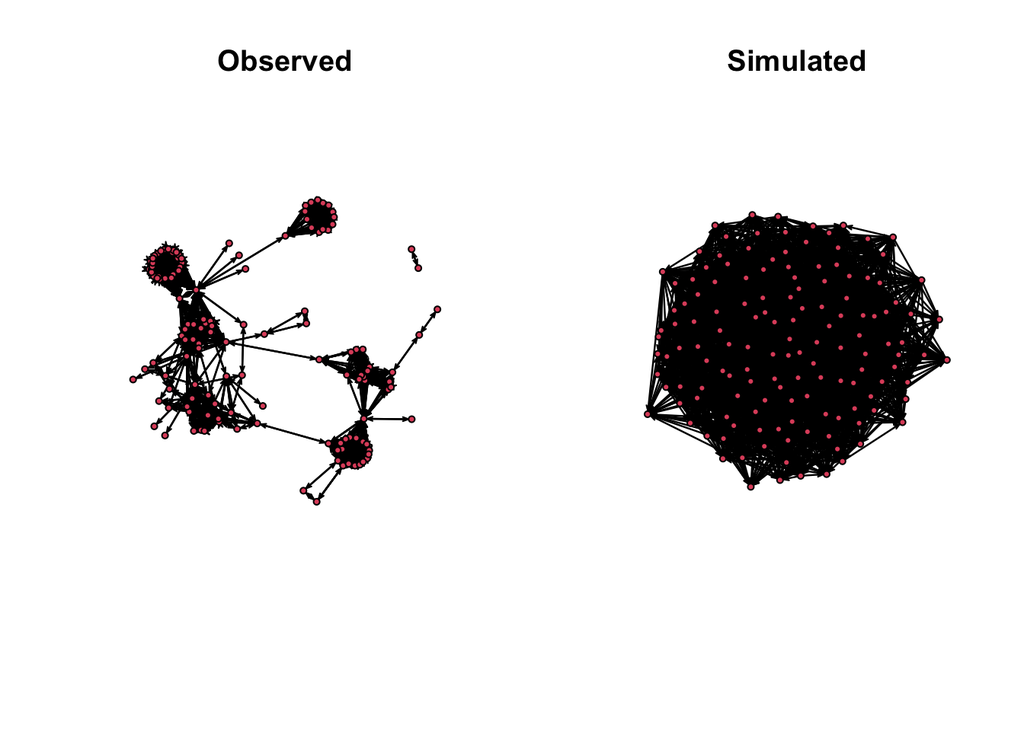

```r
par(mfrow=c(1,2))
plot(alliance2, main="Observed")
plot(sim, main="Simulated")
```

Descriptive Statistics Looking at Homophily in Network Alliances

```r
#Exploring homophily of attributes by looking at if it coincides with walktrap algorithm (tried different communnity algorithm, this one fit best)
library(igraph)
library(migraph)
alliance_wt_4<-cluster_walktrap(alliance) #walktrap with 4 steps
summary(alliance)
```

```
## IGRAPH eeb09a1 DN-- 141 3114 --
## + attr: name (v/c), Region (v/c), PR (v/c), hdi (v/c), color (v/c)
```

```r
## Preparations: Coloring Nodes

###color nodes according to Regions
library(igraph)
alliance_Region<-alliance
V(alliance_Region)$Region
```

```
##   [1] "Europe"   "Europe"   "Americas" "Americas" "Americas" "Americas"
##   [7] "Americas" "SSA"      "SSA"      "SSA"      "MENA"     "MENA"
##  [13] "MENA"     "MENA"     "SSA"      "MENA"     "MENA"     "MENA"
##  [19] "MENA"     "MENA"     "MENA"     "MENA"     "MENA"     "MENA"
##  [25] "MENA"     "MENA"     "MENA"     "Americas" "Americas" "Americas"
##  [31] "Americas" "Americas" "Americas" "Americas" "Americas" "Americas"
##  [37] "Americas" "Americas" "Americas" "Americas" "Americas" "Americas"
##  [43] "Americas" "Americas" "Americas" "Americas" "Americas" "Americas"
##  [49] "Americas" "Americas" "Americas" "Americas" "Americas" "Americas"
##  [55] "Americas" "Americas" "Europe"   "Europe"   "Europe"   "Europe"
##  [61] "Europe"   "Europe"   "Europe"   "Europe"   "Europe"   "Europe"
##  [67] "Europe"   "Europe"   "Europe"   "Europe"   "Europe"   "Asia"
##  [73] "Asia"     "Asia"     "Asia"     "Asia"     "SSA"      "SSA"
##  [79] "Asia"     "Asia"     "SSA"      "SSA"      "Asia"     "SSA"
##  [85] "SSA"      "SSA"      "SSA"      "SSA"      "SSA"      "SSA"
##  [91] "SSA"      "SSA"      "SSA"      "SSA"      "SSA"      "SSA"
##  [97] "SSA"      "SSA"      "Other"    "Eurasia"  "Europe"   "Europe"
## [103] "Eurasia"  "Europe"   "Eurasia"  "Eurasia"  "Eurasia"  "Eurasia"
## [109] "Eurasia"  "Eurasia"  "Eurasia"  "Eurasia"  "Eurasia"  "Eurasia"
## [115] "Europe"   "Europe"   "Europe"   "Europe"   "Asia"     "Europe"
## [121] "Europe"   "MENA"     "Other"    "Europe"   "SSA"      "SSA"
## [127] "SSA"      "SSA"      "SSA"      "SSA"      "SSA"      "SSA"
## [133] "SSA"      "SSA"      "SSA"      "MENA"     "Asia"     "SSA"
## [139] "SSA"      "SSA"      "SSA"
```

```r
V(alliance_Region)$color<-"white"

V(alliance_Region)$color <- ifelse(V(alliance_Region)$Region == "Americas", "blue", ifelse(V(alliance_Region)$Region == "Europe", "red", ifelse(V(alliance_Region)$Region == "MENA", "green", ifelse(V(alliance_Region)$Region == "SSA", "yellow", ifelse(V(alliance_Region)$Region == "Asia", "orange", ifelse(V(alliance_Region)$Region == "Eurasia", "darkgreen", "white"))))))

###color nodes according to hdi
alliance_hdi<-alliance
V(alliance_hdi)$hdi
```

```
##   [1] "high"   "high"   "medium" "low"    "low"    "medium" "medium" "low"
##   [9] "medium" "low"    "low"    "medium" "medium" "medium" "low"    "low"
##  [17] "low"    "low"    "medium" "medium" "high"   "low"    "high"   "high"
##  [25] "high"   "high"   "high"   "high"   "high"   "high"   "low"    "medium"
##  [33] "medium" "medium" "high"   "medium" "medium" "medium" "medium" "medium"
##  [41] "medium" "medium" "low"    "low"    "low"    "low"    "low"    "medium"
##  [49] "medium" "low"    "medium" "medium" "medium" "high"   "high"   "high"
##  [57] "high"   "high"   "high"   "high"   "high"   "high"   "high"   "high"
##  [65] "high"   "high"   "high"   "high"   "high"   "high"   "medium" "low"
##  [73] "high"   "high"   "high"   "low"    "low"    "low"    "medium" "medium"
##  [81] "low"    "low"    "low"    "medium" "low"    "low"    "low"    "low"
##  [89] "low"    "low"    "medium" "low"    "low"    "low"    "low"    "low"
##  [97] "low"    "low"    "low"    "high"   "high"   "high"   "medium" "high"
## [105] "medium" "high"   "medium" "medium" "medium" "low"    "low"    "low"
## [113] "low"    "medium" "medium" "high"   "high"   "high"   "medium" "high"
## [121] "high"   "high"   "medium" "medium" "low"    "low"    "medium" "low"
## [129] "low"    "low"    "low"    "low"    "low"    "low"    "low"    "medium"
## [137] "low"    "low"    "medium" "low"    "low"
```

```r
V(alliance_hdi)$color<-"white"

V(alliance_hdi)$color <- ifelse(V(alliance_hdi)$hdi == "low", "yellow", ifelse(V(alliance_hdi)$hdi == "medium", "orange", ifelse(V(alliance_hdi)$hdi == "high", "red", "white")))

###color nodes according to PR
alliance_PR<-alliance
V(alliance_PR)$PR
```

```
##   [1] "low"    "low"    "medium" "medium" "medium" "medium" "medium" "high"
##   [9] "high"   "high"   "medium" "high"   "medium" "medium" "high"   "high"
##  [17] "medium" "high"   "medium" "high"   "high"   "high"   "medium" "high"
##  [25] "high"   "high"   "high"   "low"    "low"    "low"    "medium" "low"
##  [33] "low"    "low"    "low"    "low"    "low"    "low"    "low"    "low"
##  [41] "low"    "medium" "low"    "medium" "medium" "low"    "medium" "low"
##  [49] "low"    "low"    "low"    "low"    "low"    "low"    "low"    "low"
##  [57] "low"    "low"    "low"    "low"    "low"    "low"    "low"    "low"
##  [65] "low"    "low"    "low"    "low"    "low"    "low"    "medium" "medium"
##  [73] "low"    "low"    "low"    "medium" "medium" "high"   "high"   "high"
##  [81] "medium" "high"   "low"    "low"    "high"   "high"   "high"   "low"
##  [89] "low"    "medium" "medium" "medium" "medium" "low"    "low"    "medium"
##  [97] "medium" "low"    "medium" "high"   "low"    "low"    "medium" "low"
## [105] "medium" "high"   "medium" "medium" "high"   "high"   "high"   "medium"
## [113] "high"   "high"   "medium" "low"    "low"    "low"    "low"    "low"
## [121] "low"    "low"    "medium" "medium" "medium" "high"   "high"   "low"
## [129] "high"   "high"   "high"   "medium" "high"   "high"   "high"   "high"
## [137] "high"   "medium" "medium" "medium" "high"
```

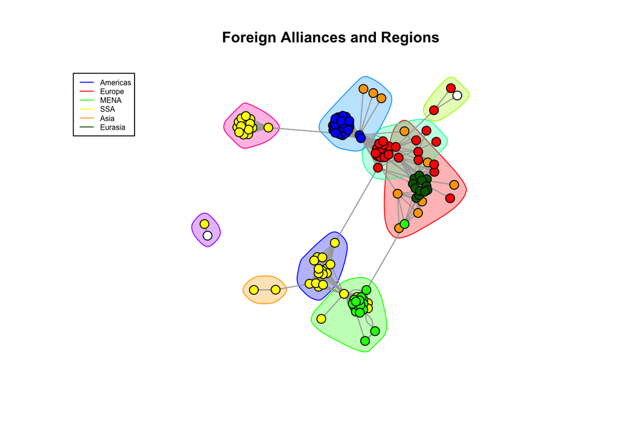

```r
V(alliance_PR)$color<-"white"

V(alliance_PR)$color <- ifelse(V(alliance_PR)$PR == "low", "red", ifelse(V(alliance_PR)$PR == "medium", "orange", ifelse(V(alliance_PR)$PR == "high", "yellow", "white")))

##Plots Community Algorithm and Node Attributes

plot(alliance_Region, vertex.size = 7, label.size = .1, vertex.label = NA, edge.arrow.size = 0.1 , edge.arrow.width = 0.5, mark.groups = alliance_wt_4)
title(main = "Foreign Alliances and Regions", cex.main = 1, col.main = "black") ##plot Regions
legend("topleft", legend=c("Americas", "Europe", "MENA", "SSA", "Asia", "Eurasia"),
       col=c("blue", "red", "green", "yellow", "orange", "darkgreen"), lty=1:1, cex=0.5)
```

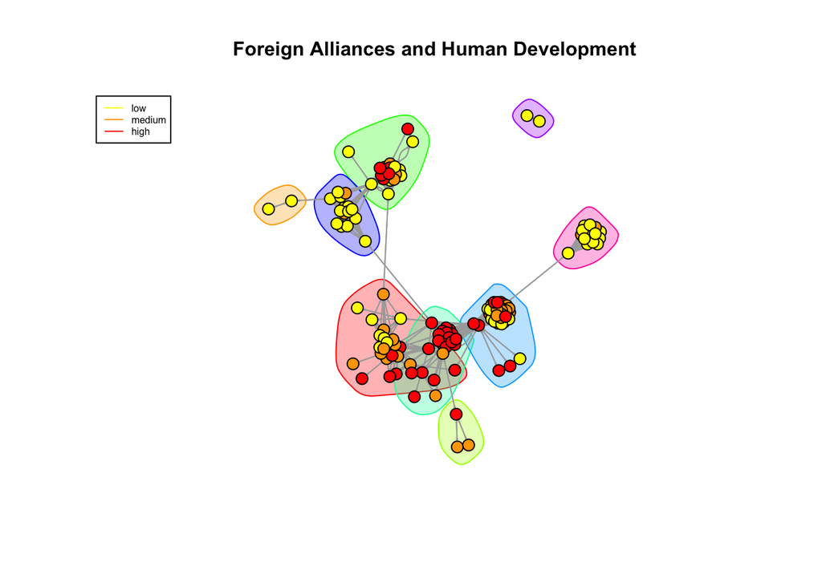

```r
plot(alliance_hdi, vertex.size = 7, label.size = .1, vertex.label = NA, edge.arrow.size = 0.1 , edge.arrow.width = 0.5, mark.groups = alliance_wt_4)
title(main = "Foreign Alliances and Human Development", cex.main = 1, col.main = "black") ##plot hdi
legend("topleft", legend=c("low", "medium", "high"),
       col=c("yellow", "orange", "red"), lty=1:1, cex=0.5)
```

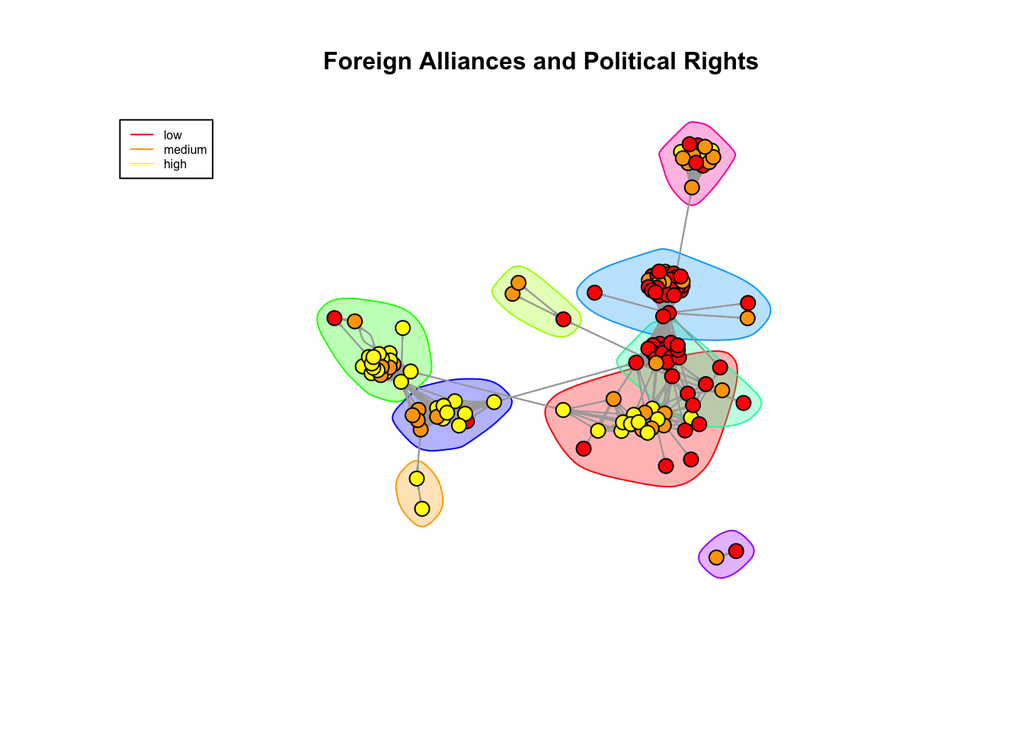

```r
plot(alliance_PR, vertex.size = 7, label.size = .1, vertex.label = NA, edge.arrow.size = 0.1 , edge.arrow.width = 0.5, mark.groups = alliance_wt_4)
title(main = "Foreign Alliances and Political Rights", cex.main = 1, col.main = "black") ##plot PR
legend("topleft", legend=c("low", "medium", "high"),
       col=c("red", "orange", "yellow"), lty=1:1, cex=0.5)
```

We can see that to a certain extent, alliance communities seem to coincide with regions, political rights and human development. Clusters seem most homophile with regard to regions, and less clear with regard to the other two attributes. As a next step, let’s examine this structural hypothesis causally, before also taking into account different levels of dependencies.